# Statistical analysis notebook

###### *This notebook is Part 3 of “Introductory Big Data Analyses to gain insights in Precision Medicine” course.*

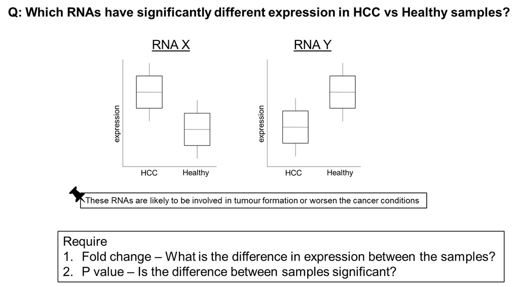

Which statistical test is suitable?

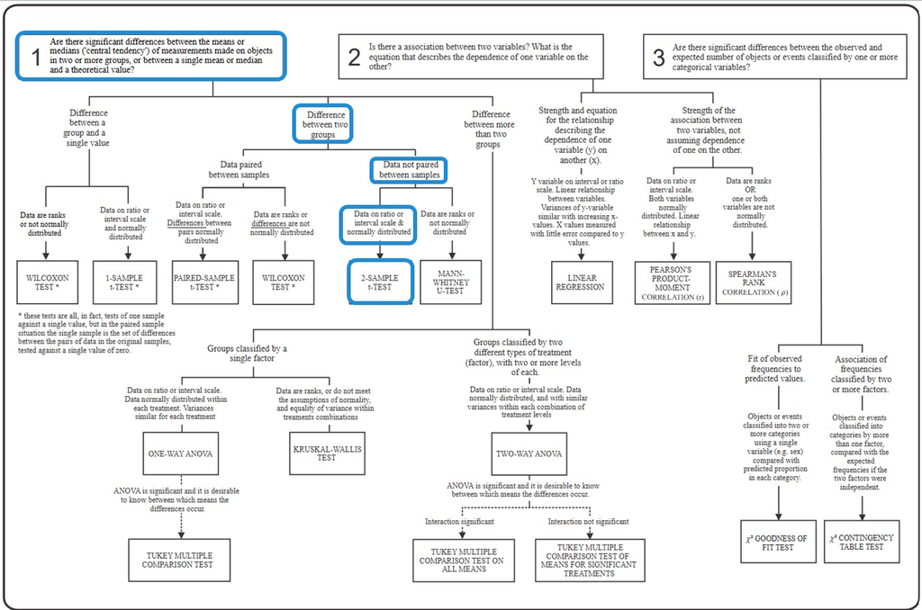

*Reference: [A Choosing models and tests | APS 240: Data Analysis and Statistics with R (dzchilds.github.io)](https://dzchilds.github.io/stats-for-bio/choosing-models-and-tests.html)*

## Step 2 Statistical analysis

#### 1. Install R packages for T-test calculation on each rows

```r
install.packages('matrixTests',dependencies=TRUE)
library(matrixTests)
```

#### 2. Perform Welch’s T-test (Independent T-test) on (log-transformed) normalized data

```r
#row_t_welch(columns for treatment group, columns for control group)
hcchealthyttest<-row_t_welch(hcc_healthy_log[,grepl("HCC", names(hcc_healthy_log))] , hcc_healthy_log[,grepl("Healthy", names(hcc_healthy_log))], alternative = "two.sided")
```

#### 3. Multiple test correction

*Rationale:*

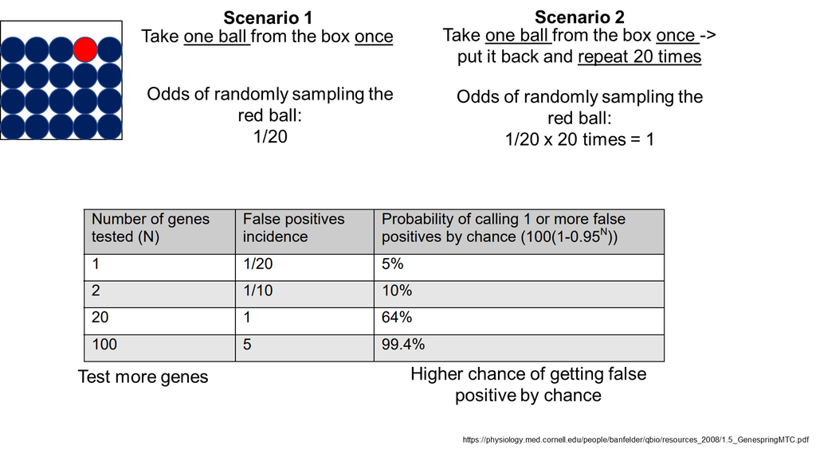

*Methods:*

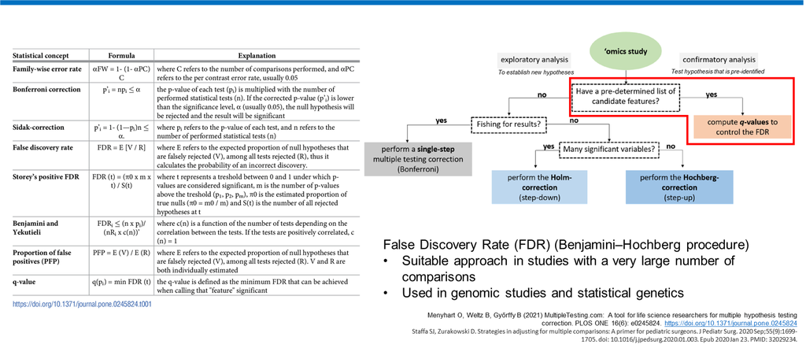

```r
#p.adjust(column that contains P value,"which correction method")
hcchealthyttest$FDR <- p.adjust(hcchealthyttest$pvalue, "BH")
```

#### 4. Calculate Fold Change (FC)

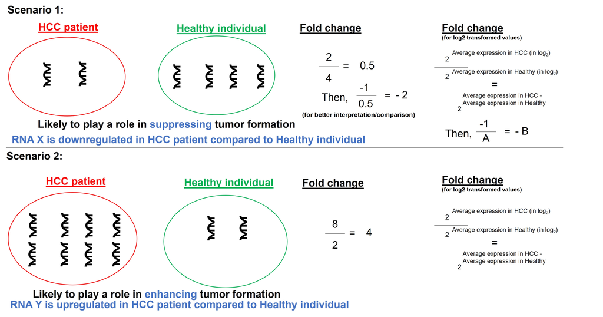

```r
#create new column (FC)
hcchealthyttest$FC <- 2^(hcchealthyttest$mean.x-hcchealthyttest$mean.y)
```

#### 5. Convert FC<1 to negative values (Downregulated genes)

```r
#convert those FC with values smaller than 1 to negative fold change
#for better interpretation/comparison with those FC values>1
#create new column (finalfc)
#ifelse(if this condition, then do this, if not do this instead)
hcchealthyttest$finalfc <- ifelse(hcchealthyttest$FC <1, -1/hcchealthyttest$FC,hcchealthyttest$FC)
```

### Exercise 1

1. a. Identify genes that pass **FDR**<=0.05 and |FC|>=**1.5**. Name the new dataset as fdr005fc1.5

   b. Repeat step a and b by changing the criteria to
   1. **FDR**<=0.05 and |FC|>=**2,** Name the new dataset as fdr005fc2
   2. **P value**<=0.05 and |FC|>=**1.5,** Name the new dataset as p005fc1.5
   3. **P value**<=0.05 and |FC|>=**2,** Name the new dataset as p005fc2

   d. Summarize how many genes that pass the criteria =

| FDR or P value <=0.05 | FC criteria | Number of genes that passed both criteria |
| --- | --- | --- |
| FDR<=0.05 | \|FC\|>=1.5 | ? |
| FDR<=0.05 | \|FC\|>=2 | ? |
| P<=0.05 | \|FC\|>=1.5 | ? |
| P<=0.05 | \|FC\|>=2 | ? |

```r
#filter according to FDR and FC
fdr005fc1.5<-filter(hcchealthyttest,FDR<=0.05 & abs(finalfc)>=1.5)
#429

fdr005fc2<-filter(hcchealthyttest,FDR<=0.05 & abs(finalfc)>=2)
#85

p005fc1.5<-filter(hcchealthyttest,pvalue<=0.05 & abs(finalfc)>=1.5)
#497

p005fc2<-filter(hcchealthyttest,pvalue<=0.05 & abs(finalfc)>=2)
#85
```

## Step 3b Data visualization

### i) Heatmap - Visualize all significantly differentially expressed lncRNAs/mRNAs between all HCC and healthy samples

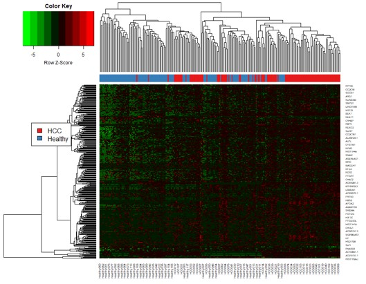

#### 1. Install R packages for heatmap

```r
install.packages("gplots")
```

#### 2. Load the packages

```r
library(gplots)
```

#### 3. Obtain expression data for differentially expressed RNAs

```r
library(dplyr)
#filter(which dataset(rownames of this dataset)%in% (also appear in rownames of another dataset))
#need to change the dataset name (sigbyfdr)
sigrnaexp<-filter(hcc_healthy_log,rownames(hcc_healthy_log) %in% rownames(fdr005fc1.5))
```

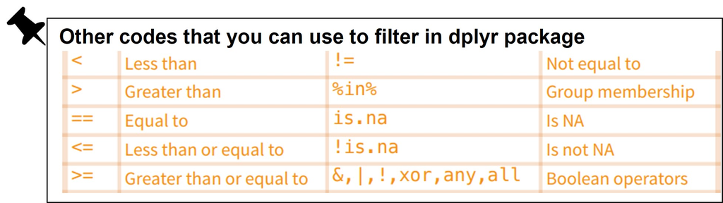

*Reference:* [*https://www.rstudio.com/wp-content/uploads/2015/02/data-wrangling-cheatsheet.pdf*](https://www.rstudio.com/wp-content/uploads/2015/02/data-wrangling-cheatsheet.pdf)

#### 4. Convert data frame to matrix for heatmap

```r
#as.matrix(data frame name)
sigrnaexp_mat<-as.matrix(sigrnaexp)
```

#### 5. Specify two groups that you wish to compare and colours for each group

```r
#in order to specify hcc and healthy group as a new variable, we keep only the first 3 characters of column names
#substr(column name of the dataset,start from which element, stop at which element)
#convert the characters as factor
my_group<-as.factor(substr(colnames(sigrnaexp),1,3))
```

#### 6. Install package for colour palettes

```r
install.packages("RcolorBrewer")
```

#### 7. Load the package

```r
library(RColorBrewer)
```

#### 8. View the available colour palettes

```r
display.brewer.all()
```

#### 9. Specify colours for the groups (on top of heatmap)

```r
#specify colours that you want for the two groups
colSide<-brewer.pal(9,"Set1")[my_group]
```

#### 10. Specify colours for gene expression on heatmap (red : upregulated; green: downregulated; black: low expression)

```r
colgradient<-colorRampPalette(c("green","black","red"))(10)
```

#### 11. Draw heatmap

```r
heatmap.2(sigrnaexp_mat,col=colgradient,scale="row",trace="none",ColSideColors = colSide, density.info="none")
```

#### 12. Add Figure legend

```r
legend(x="left",legend=c("HCC","Healthy"),fill=brewer.pal(9,"Set1"))
```

### ii) Volcano plot - Visualize significantly differentially expressed lncRNAs/mRNAs in HCC patients vs Healthy individuals

```r
#create a new column called gene_symbol
hcchealthyttest$gene_symbol<-row.names(hcchealthyttest)

#create another new column called diffexpressed
hcchealthyttest$diffexpressed <- "NO"
# if log2Foldchange > 1.5 and FDR < 0.05, set as "UP"
hcchealthyttest$diffexpressed[hcchealthyttest$finalfc > 1.5 & hcchealthyttest$FDR < 0.05] <- "UP"
# if log2Foldchange < -1.5 and FDR < 0.05, set as "DOWN"
hcchealthyttest$diffexpressed[hcchealthyttest$finalfc < -1.5 & hcchealthyttest$FDR < 0.05] <- "DOWN"

#create a new column called delabel - to label those not differentially expressed as No
hcchealthyttest$delabel <- NA
hcchealthyttest$delabel[hcchealthyttest$diffexpressed != "NO"] <- hcchealthyttest$gene_symbol[hcchealthyttest$diffexpressed != "NO"]

#simple volcano plot
library(ggplot2)
ggplot(data=hcchealthyttest, aes(x=finalfc, y=-log10(FDR), col=diffexpressed, label=delabel)) +
  geom_point() +
  theme_minimal() +
  geom_text()
```

1. Install a new package to organize the labels

```r
install.packages("ggrepel")
```

2. Load the package and draw volcano plot

```r
# load library
library(ggrepel)
# plot adding up all layers we have seen so far
ggplot(data=hcchealthyttest, aes(x=finalfc, y=-log10(FDR), col=diffexpressed, label=delabel)) +
  geom_point() +
  theme_minimal() +
  geom_text_repel() +
  scale_color_manual(values=c("blue", "black", "red")) +
  geom_vline(xintercept=c(-0.6, 0.6), col="red") +
  geom_hline(yintercept=-log10(0.05), col="red")
```

### iii) Boxplot - Visualize individual differentially expressed lncRNAs/mRNAs in HCC patients vs Healthy individuals

In this example, we will draw boxplot on the most upregulated gene

#### 1. Install R packages for boxplots

```r
install.packages("ggplot2")
```

#### 2. Load the package

```r
library(ggplot2)
```

#### 3. Sort the FC and FDR or find the max values of FC

```r
#to sort based on a column in ascending order
#order(dataframe$column names)

#sort in descending order
#order(-dataframe$column names)

#sort based on multiple columns
#order(dataframe$column 1 name, dataframe$column 2 name)
sigrnaexp_sorted<-sigrnaexp[order(-fdr005fc1.5$finalfc,fdr005fc1.5$FDR),]
```

#### 4. Convert the data into long format (contains value in only one column)

Example of data in wide format and long format :

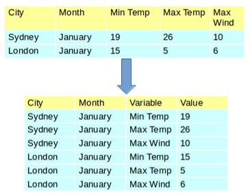

*Reference: https://www.r-bloggers.com/2016/09/reshape-r-package-reshape2-melt-and-cast/*

```r
#install package that reshape data and install
install.packages("reshape")
library(reshape)
```

```r
#melt the first row (that contains the most upregulated gene) into long format
#melt(dataframe)
rna1<-melt((sigrnaexp_sorted[1,]))
```

### Exercise 2

#### 5. Convert HCC and healthy sample IDs to just HCC or Healthy label

In this example, we create a new column (Column name is “Sampletypes”)

eg. recode “HCC001”, “HCC002”etc to “HCC” in “Sampletypes” column while “Healthy001”,“Healthy002”etc to “Healthy” in “Sampletypes” column

```r
rna1_rename<-rna1%>%mutate(Sampletypes=case_when(grepl("HCC",rna1$variable)~"HCC",grepl("Healthy",rna1$variable)~"Healthy"))
```

#### 6. Draw boxplot using ggplot function

Hint: use geom_boxplot()

```r
ggplot(rna1_rename,aes(x=Sampletypes,y=value))+geom_boxplot()
```

## Additional information that may be useful

- Export data

```r
install.packages("writexl")
library(writexl)
write.xlsx(sigrnaexp,"sigrnaexp.xlsx")
```

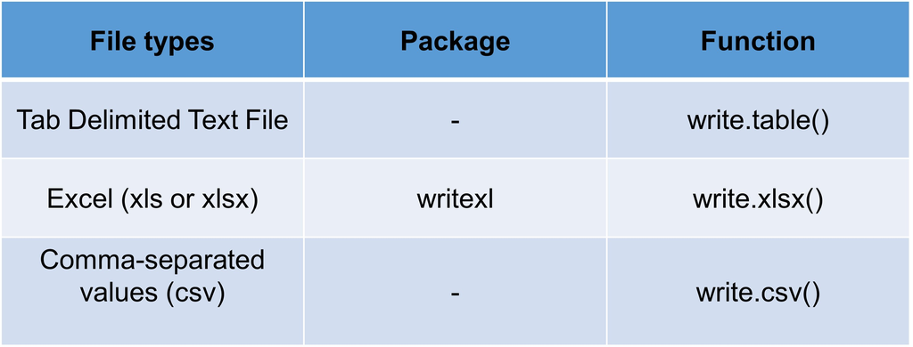

- Obtain data insights (pathways of the differentially expressed genes)
  - Visit cpdb molgen website (http://cpdb.molgen.mpg.de/)

The End of Part 3